# Fundamentos de Aprendizaje Automático

## Práctica 2

### Alfonso Bonilla Trueba y Mónica de la Iglesia Martínez

#### Apartado 1

**Anotación:** *En KNN solo hacemos plot del mejor valor de K para validación Simple, para evitar tener 6 gráficas por cada fichero*

```python
%run TasasClasificador.py ./ConjuntosDatos/example1.data --KNN --norm --k 1 3 5 11 21 51
```

```
  Fichero:  example1.data
  - Porcentaje Entrenamiento en Validacion simple 70.00%
  - Numero de Particiones en Validacion cruzada:  5
  - Usando nuestra libreria
----------------------------------------------------
Usando Validacion Simple
  Error del 21.67% KNN con k = 1
  Error del 16.67% KNN con k = 3
  Error del 18.33% KNN con k = 5
  Error del 17.50% KNN con k = 11
  Error del 18.33% KNN con k = 21
  Error del 15.83% KNN con k = 51
Usando Validacion Cruzada
  Error del 16.75% Desviacion del 2.57% KNN con k = 1
  Error del 15.75% Desviacion del 3.02% KNN con k = 3
  Error del 15.00% Desviacion del 1.58% KNN con k = 5
  Error del 14.50% Desviacion del 2.03% KNN con k = 11
  Error del 15.00% Desviacion del 2.37% KNN con k = 21
  Error del 13.75% Desviacion del 3.35% KNN con k = 51
```

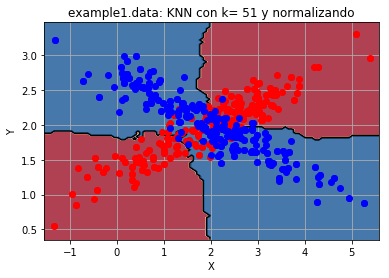

```python
%run TasasClasificador.py ./ConjuntosDatos/example1.data --KNN --norm --k 51 --plot
```

Fijándonos en como están distribuidos los datos vemos que en el centro de la grafica están mezcladas ambas clases que es donde se produce el error, puesto que la frontera no es perfecta, en cambio, en los extremos no están mezclados, por lo que la frontera diferencia bien las clases. Esto hace que el error que tenemos no supere practicamente el 20% porque el único punto conflictivo es el centro, el resto de datos están bien separados, por lo que la comprobacion con los vecinos predice la clase correcta

```python
%run TasasClasificador.py ./ConjuntosDatos/example2.data --KNN --norm --k 1 3 5 11 21 51
```

```
  Fichero:  example2.data
  - Porcentaje Entrenamiento en Validacion simple 70.00%
  - Numero de Particiones en Validacion cruzada:  5
  - Usando nuestra libreria
----------------------------------------------------
Usando Validacion Simple
  Error del 0.00% KNN con k = 1
  Error del 0.00% KNN con k = 3
  Error del 0.00% KNN con k = 5
  Error del 0.00% KNN con k = 11
  Error del 0.00% KNN con k = 21
  Error del 0.00% KNN con k = 51
Usando Validacion Cruzada
  Error del 0.00% Desviacion del 0.00% KNN con k = 1
  Error del 0.00% Desviacion del 0.00% KNN con k = 3
  Error del 0.00% Desviacion del 0.00% KNN con k = 5
  Error del 0.00% Desviacion del 0.00% KNN con k = 11
  Error del 0.00% Desviacion del 0.00% KNN con k = 21
  Error del 0.00% Desviacion del 0.00% KNN con k = 51
```

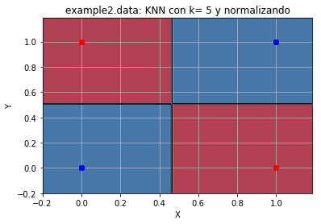

```python
%run TasasClasificador.py ./ConjuntosDatos/example2.data --KNN --norm --k 5 --plot
```

En este fichero vemos que los datos están agrupados en 4 posibles puntos, esto es porque si miramos el fichero de datos, son todos nominales y la clase datos los convierte en enteros, de 0 en adelante. Por esto tenemos los datos muy bien diferenciados, y no están dispersos. Esto hace que KNN de una tasa de error de 0% con los valores de k que hemos introducido. En cada punto hay una media aproximada de unos 100 puntos (aproximadamente) es por esto que acierta. Pero si introducimos un valor de k mayor entonces empiza a contar como cercanos puntos que no pertenecen a su clase y la tasa de error aumenta.

Por ejemplo hemos probado a ejecutarlo con k=130 y hemos obtenido una tasa de error en validación simple de 29.17% por lo que hemos comentado.

```python
%run TasasClasificador.py ./ConjuntosDatos/example3.data --KNN --norm --k 1 3 5 11 21 51
```

```
  Fichero:  example3.data
  - Porcentaje Entrenamiento en Validacion simple 70.00%
  - Numero de Particiones en Validacion cruzada:  5
  - Usando nuestra libreria
----------------------------------------------------
Usando Validacion Simple
  Error del 5.83% KNN con k = 1
  Error del 5.00% KNN con k = 3
  Error del 5.00% KNN con k = 5
  Error del 4.17% KNN con k = 11
  Error del 1.67% KNN con k = 21
  Error del 5.83% KNN con k = 51
Usando Validacion Cruzada
  Error del 6.00% Desviacion del 3.10% KNN con k = 1
  Error del 5.75% Desviacion del 3.02% KNN con k = 3
  Error del 5.25% Desviacion del 3.20% KNN con k = 5
  Error del 5.25% Desviacion del 2.67% KNN con k = 11
  Error del 6.00% Desviacion del 3.48% KNN con k = 21
  Error del 7.25% Desviacion del 3.10% KNN con k = 51
```

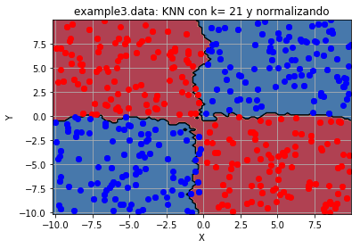

```python
%run TasasClasificador.py ./ConjuntosDatos/example3.data --KNN --norm --k 21 --plot
```

En este fichero vemos que hay dispesion de datos, pero dentro de la dispersion estan aislados en 4 grandes grupos, por tanto, KNN al comprobar con los mas cercanos tiene una tasa de error baja. Cerca de la frontera es donde tiene mas posibilidad de fallar, pues entre sus vecinos proximos se encuentran tambien algunos de la clase opuesta a la real.

```python
%run TasasClasificador.py ./ConjuntosDatos/example4.data --KNN --norm --k 1 3 5 11 21 51
```

```
  Fichero:  example4.data
  - Porcentaje Entrenamiento en Validacion simple 70.00%
  - Numero de Particiones en Validacion cruzada:  5
  - Usando nuestra libreria
----------------------------------------------------
Usando Validacion Simple
  Error del 0.00% KNN con k = 1
  Error del 0.00% KNN con k = 3
  Error del 0.00% KNN con k = 5
  Error del 0.00% KNN con k = 11
  Error del 0.00% KNN con k = 21
  Error del 0.00% KNN con k = 51
Usando Validacion Cruzada
  Error del 0.00% Desviacion del 0.00% KNN con k = 1
  Error del 0.00% Desviacion del 0.00% KNN con k = 3
  Error del 0.00% Desviacion del 0.00% KNN con k = 5
  Error del 0.00% Desviacion del 0.00% KNN con k = 11
  Error del 0.00% Desviacion del 0.00% KNN con k = 21
  Error del 0.00% Desviacion del 0.00% KNN con k = 51
```

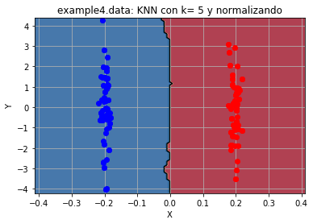

```python
%run TasasClasificador.py ./ConjuntosDatos/example4.data --KNN --norm --k 5 --plot
```

Podemos observare en la gráfica que los datos estan muy bien separados, con una dispersión vertical, pero no se entremezclan las clases. Por esto la frontera divide perfectamente a ambas clases, y la tasa de error de knn es 0% para los valores de k introducidos.

Igual que ocurría en el fichero example2.data, si aumentamos demasiado el valor de k, la tasa de error comenzará a aumentar puesto que estaras tomando como proximos los puntos de la clase opuesta, y por tanto realizando predicciones erroneas.

##### Sin normalización de Datos

```python
%run TasasClasificador.py ./ConjuntosDatos/example1.data --KNN --k 1 3 5 11 21 51
```

```
  Fichero:  example1.data
  - Porcentaje Entrenamiento en Validacion simple 70.00%
  - Numero de Particiones en Validacion cruzada:  5
  - Usando nuestra libreria
----------------------------------------------------
Usando Validacion Simple
  Error del 14.17% KNN con k = 1
  Error del 14.17% KNN con k = 3
  Error del 12.50% KNN con k = 5
  Error del 13.33% KNN con k = 11
  Error del 11.67% KNN con k = 21
  Error del 11.67% KNN con k = 51
Usando Validacion Cruzada
  Error del 15.50% Desviacion del 6.05% KNN con k = 1
  Error del 14.25% Desviacion del 4.37% KNN con k = 3
  Error del 14.00% Desviacion del 6.09% KNN con k = 5
  Error del 13.25% Desviacion del 5.28% KNN con k = 11
  Error del 13.75% Desviacion del 6.22% KNN con k = 21
  Error del 15.75% Desviacion del 6.35% KNN con k = 51
```

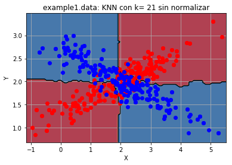

```python
%run TasasClasificador.py ./ConjuntosDatos/example1.data --KNN --k 21 --plot
```

```python
%run TasasClasificador.py ./ConjuntosDatos/example2.data --KNN --k 1 3 5 11 21 51
```

```
  Fichero:  example2.data
  - Porcentaje Entrenamiento en Validacion simple 70.00%
  - Numero de Particiones en Validacion cruzada:  5
  - Usando nuestra libreria
----------------------------------------------------
Usando Validacion Simple
  Error del 0.00% KNN con k = 1
  Error del 0.00% KNN con k = 3
  Error del 0.00% KNN con k = 5
  Error del 0.00% KNN con k = 11
  Error del 0.00% KNN con k = 21
  Error del 0.00% KNN con k = 51
Usando Validacion Cruzada
  Error del 0.00% Desviacion del 0.00% KNN con k = 1
  Error del 0.00% Desviacion del 0.00% KNN con k = 3
  Error del 0.00% Desviacion del 0.00% KNN con k = 5
  Error del 0.00% Desviacion del 0.00% KNN con k = 11
  Error del 0.00% Desviacion del 0.00% KNN con k = 21
  Error del 0.00% Desviacion del 0.00% KNN con k = 51
```

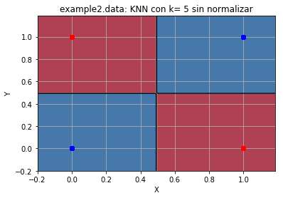

```python
%run TasasClasificador.py ./ConjuntosDatos/example2.data --KNN --k 5 --plot
```

Este fichero como ya comentamos son datos nominales, por tanto normalizar o no normalizar no afecta y se obtiene la misma gráfica con la misma tasa de errores del 0%

Como conclusión sacamos que para este tipo de ficheros de datos, donde estos son Nominales es mejor no usar normalización, puesto que computacionalmente nos ahorramos el paso de calcular medias y desviaciones.

```python
%run TasasClasificador.py ./ConjuntosDatos/example3.data --KNN --k 1 3 5 11 21 51
```

```
  Fichero:  example3.data
  - Porcentaje Entrenamiento en Validacion simple 70.00%
  - Numero de Particiones en Validacion cruzada:  5
  - Usando nuestra libreria
----------------------------------------------------
Usando Validacion Simple
  Error del 3.33% KNN con k = 1
  Error del 4.17% KNN con k = 3
  Error del 3.33% KNN con k = 5
  Error del 0.83% KNN con k = 11
  Error del 5.00% KNN con k = 21
  Error del 5.83% KNN con k = 51
Usando Validacion Cruzada
  Error del 2.50% Desviacion del 1.58% KNN con k = 1
  Error del 4.25% Desviacion del 2.32% KNN con k = 3
  Error del 3.25% Desviacion del 1.70% KNN con k = 5
  Error del 2.00% Desviacion del 1.00% KNN con k = 11
  Error del 3.00% Desviacion del 1.27% KNN con k = 21
  Error del 4.25% Desviacion del 1.27% KNN con k = 51
```

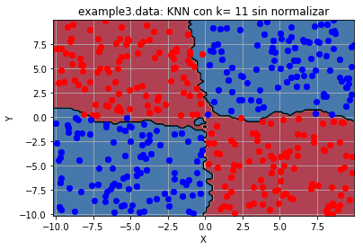

```python
%run TasasClasificador.py ./ConjuntosDatos/example3.data --KNN --k 11 --plot
```

En esta gráfica los datos estan dispersos pero agrupados por su clase, es decir, no están mezclados. Las tasas de error son similares a cuando usamos normalización, lo que nos hace pensar que los datos estan todos en la misma escala y por tanto la normalización no es necesaria, y si se realiza se obtiene el mismo gráfico y casi las mismas tasas de error.

```python
%run TasasClasificador.py ./ConjuntosDatos/example4.data --KNN --k 1 3 5 11 21 51
```

```
  Fichero:  example4.data
  - Porcentaje Entrenamiento en Validacion simple 70.00%
  - Numero de Particiones en Validacion cruzada:  5
  - Usando nuestra libreria
----------------------------------------------------
Usando Validacion Simple
  Error del 3.33% KNN con k = 1
  Error del 6.67% KNN con k = 3
  Error del 23.33% KNN con k = 5
  Error del 23.33% KNN con k = 11
  Error del 56.67% KNN con k = 21
  Error del 63.33% KNN con k = 51
Usando Validacion Cruzada
  Error del 5.00% Desviacion del 7.75% KNN con k = 1
  Error del 10.00% Desviacion del 5.48% KNN con k = 3
  Error del 12.00% Desviacion del 6.78% KNN con k = 5
  Error del 24.00% Desviacion del 13.93% KNN con k = 11
  Error del 54.00% Desviacion del 8.00% KNN con k = 21
  Error del 66.00% Desviacion del 11.58% KNN con k = 51
```

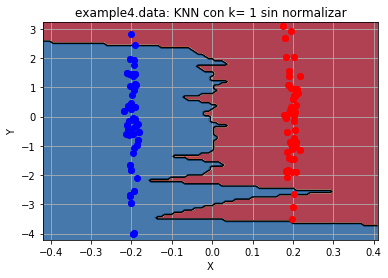

```python
%run TasasClasificador.py ./ConjuntosDatos/example4.data --KNN --k 1 --plot
```

En esta gráfica si que observamos que la frontera se ha dibujado muy mal en comparación con la gráfica en la que si usamos normalización que era casi una línea recta.

En cuanto a la tasa de error, comparando con la anterior vemos que normalizando teníamos una tasa de error del 0% y aqui ha aumentado conforme ha ido aumentando el valor de k.

##### Usando la libreria Sklearn

```python
%run TasasClasificador.py ./ConjuntosDatos/example1.data --KNN --sklearn --k 1 3 5 11 21 51
```

```
  Fichero:  example1.data
  - Porcentaje Entrenamiento en Validacion simple 70.00%
  - Numero de Particiones en Validacion cruzada:  5
  - Usando la libreria Sklearn
----------------------------------------------------
Usando Validacion Simple
  Error del 19.01% KNN con k = 1
  Error del 12.40% KNN con k = 3
  Error del 12.40% KNN con k = 5
  Error del 14.88% KNN con k = 11
  Error del 12.40% KNN con k = 21
  Error del 14.05% KNN con k = 51
Usando Validacion Cruzada
  Error del 17.50% Desviacion del 2.09% KNN con k = 1
  Error del 14.25% Desviacion del 1.27% KNN con k = 3
  Error del 14.75% Desviacion del 1.84% KNN con k = 5
  Error del 13.00% Desviacion del 4.37% KNN con k = 11
  Error del 14.25% Desviacion del 5.62% KNN con k = 21
  Error del 15.50% Desviacion del 5.16% KNN con k = 51
```

```python
%run TasasClasificador.py ./ConjuntosDatos/example2.data --KNN --sklearn --k 1 3 5 11 21 51
```

```
  Fichero:  example2.data
  - Porcentaje Entrenamiento en Validacion simple 70.00%
  - Numero de Particiones en Validacion cruzada:  5
  - Usando la libreria Sklearn
----------------------------------------------------
Usando Validacion Simple
  Error del 0.00% KNN con k = 1
  Error del 0.00% KNN con k = 3
  Error del 0.00% KNN con k = 5
  Error del 0.00% KNN con k = 11
  Error del 0.00% KNN con k = 21
  Error del 0.00% KNN con k = 51
Usando Validacion Cruzada
  Error del 0.00% Desviacion del 0.00% KNN con k = 1
  Error del 0.00% Desviacion del 0.00% KNN con k = 3
  Error del 0.00% Desviacion del 0.00% KNN con k = 5
  Error del 0.00% Desviacion del 0.00% KNN con k = 11
  Error del 0.00% Desviacion del 0.00% KNN con k = 21
  Error del 0.00% Desviacion del 0.00% KNN con k = 51
```

```python
%run TasasClasificador.py ./ConjuntosDatos/example3.data --KNN --sklearn --k 1 3 5 11 21 51
```

```
  Fichero:  example3.data
  - Porcentaje Entrenamiento en Validacion simple 70.00%
  - Numero de Particiones en Validacion cruzada:  5
  - Usando la libreria Sklearn
----------------------------------------------------
Usando Validacion Simple
  Error del 2.48% KNN con k = 1
  Error del 1.65% KNN con k = 3
  Error del 2.48% KNN con k = 5
  Error del 1.65% KNN con k = 11
  Error del 2.48% KNN con k = 21
  Error del 4.96% KNN con k = 51
Usando Validacion Cruzada
  Error del 2.25% Desviacion del 2.15% KNN con k = 1
  Error del 3.25% Desviacion del 1.50% KNN con k = 3
  Error del 3.00% Desviacion del 1.27% KNN con k = 5
  Error del 2.50% Desviacion del 1.58% KNN con k = 11
  Error del 2.75% Desviacion del 1.46% KNN con k = 21
  Error del 3.50% Desviacion del 1.22% KNN con k = 51
```

```python
%run TasasClasificador.py ./ConjuntosDatos/example4.data --KNN --sklearn --k 1 3 5 11 21 51
```

```
  Fichero:  example4.data
  - Porcentaje Entrenamiento en Validacion simple 70.00%
  - Numero de Particiones en Validacion cruzada:  5
  - Usando la libreria Sklearn
----------------------------------------------------
Usando Validacion Simple
  Error del 3.23% KNN con k = 1
  Error del 12.90% KNN con k = 3
  Error del 9.68% KNN con k = 5
  Error del 32.26% KNN con k = 11
  Error del 48.39% KNN con k = 21
  Error del 51.61% KNN con k = 51
Usando Validacion Cruzada
  Error del 4.00% Desviacion del 5.83% KNN con k = 1
  Error del 12.00% Desviacion del 8.12% KNN con k = 3
  Error del 14.00% Desviacion del 7.35% KNN con k = 5
  Error del 22.00% Desviacion del 5.10% KNN con k = 11
  Error del 39.00% Desviacion del 8.00% KNN con k = 21
  Error del 62.00% Desviacion del 14.00% KNN con k = 51
```

#### Comparación de datos Normalizando, Sin Normalizar y Usando la librería Sklearn

Las comparaciones son solo para validación simple

- example1.data

| k | Normalizando | Sin Normalizar | Sklearn |
| --- | --- | --- | --- |
| 1 | 21,67% | 14,17% | 19,01% |
| 3 | 16,67% | 14,17% | 12,40% |
| 5 | 18,33% | 12,50% | 12,40% |
| 11 | 17,50% | 13,33% | 14,88% |
| 21 | 18,33% | 11,67% | 12,40% |
| 51 | 15,83% | 11,67% | 14,05% |

- example2.data

| k | Normalizando | Sin Normalizar | Sklearn |
| --- | --- | --- | --- |
| 1 | 0,00% | 0,00% | 0,00% |
| 3 | 0,00% | 0,00% | 0,00% |
| 5 | 0,00% | 0,00% | 0,00% |
| 11 | 0,00% | 0,00% | 0,00% |
| 21 | 0,00% | 0,00% | 0,00% |
| 51 | 0,00% | 0,00% | 0,00% |

Como ya hemos comentado anteriormente los datos de este fichero estan bien divididos y tanto normalizando como sin normalizar o usando la librería sklearn obtenemos 0% de error.

- example3.data

| k | Normalizando | Sin Normalizar | Sklearn |
| --- | --- | --- | --- |
| 1 | 5,83% | 3,33% | 2,48% |
| 3 | 5,00% | 4,17% | 1,65% |
| 5 | 5,00% | 3,33% | 2,48% |
| 11 | 4,17% | 0,83% | 1,65% |
| 21 | 1,67% | 5,00% | 2,48% |
| 51 | 5,83% | 5,83% | 4,96% |

- example4.data

| k | Normalizando | Sin Normalizar | Sklearn |
| --- | --- | --- | --- |
| 1 | 0,00% | 3,33% | 3,23% |
| 3 | 0,00% | 6,67% | 12,90% |
| 5 | 0,00% | 23,33% | 9,68% |
| 11 | 0,00% | 23,33% | 32,26% |
| 21 | 0,00% | 56,67% | 48,39% |
| 51 | 0,00% | 63,33% | 51,61% |

En este fichero, tanto sklearn como nuestro calsificador sin normalizar comenten errores, en cambio si usamos normalización en nuestro clasificador obtenemos una tasa de error del 0%, esto es porque los datos de este fichero tienen distinta escala y si no normalizamos no es realista la distancia para obtener los vecinos próximos.

#### Apartado 2

```python
%run TasasClasificador.py ./ConjuntosDatos/example1.data --regLog --epocas 4 --aprendizaje 1
```

```
  Fichero:  example1.data
  - Porcentaje Entrenamiento en Validacion simple 70.00%
  - Numero de Particiones en Validacion cruzada:  5
  - Usando nuestra libreria
----------------------------------------------------
  El error con Validacion Simple es del 55.00%
  El error medio con Validacion Cruzada es del 46.75% Con una desviacion de 2.45%
```

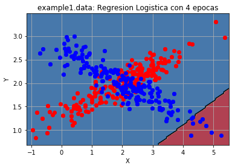

```python
%run TasasClasificador.py ./ConjuntosDatos/example1.data --regLog --epocas 4 --aprendizaje 1 --plot
```

Como vemos en esta representación de la clasificación, ha resultado ser bastante mala, puesto que clasifica a la mayoría de puntos como azules, y por tanto comete un error de 55% aproximadamente.

Tal y como son los datos es dificil dejarlos clasificados correctamente mediante una recta, pero si aumentaramos el número de épocas conseguiríamos reducir algo el error, pero no mucho.

```python
%run TasasClasificador.py ./ConjuntosDatos/example2.data --regLog --epocas 4 --aprendizaje 1
```

```
  Fichero:  example2.data
  - Porcentaje Entrenamiento en Validacion simple 70.00%
  - Numero de Particiones en Validacion cruzada:  5
  - Usando nuestra libreria
----------------------------------------------------
  El error con Validacion Simple es del 49.17%
  El error medio con Validacion Cruzada es del 32.25% Con una desviacion de 11.71%
```

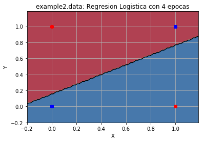

```python
%run TasasClasificador.py ./ConjuntosDatos/example2.data --regLog --epocas 4 --aprendizaje 1 --plot
```

En esta gráfica nos encontramos con el mismo problema que la anterior, clasificar todo correctamente mediante el uso de una recta es imposible, y siempre tendrá al menos un 25% de error en este fichero, puesto que la frontera pordria quedar un poco mas inclinada e incluir al punto azul de arriba, esto se podría conseguir entrenando con más épocas, pero no está garantizado.

```python
%run TasasClasificador.py ./ConjuntosDatos/example3.data --regLog --epocas 4 --aprendizaje 1
```

```
  Fichero:  example3.data
  - Porcentaje Entrenamiento en Validacion simple 70.00%
  - Numero de Particiones en Validacion cruzada:  5
  - Usando nuestra libreria
----------------------------------------------------
  El error con Validacion Simple es del 47.50%
  El error medio con Validacion Cruzada es del 44.25% Con una desviacion de 6.40%
```

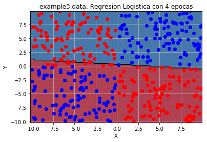

```python
%run TasasClasificador.py ./ConjuntosDatos/example3.data --regLog --epocas 4 --aprendizaje 1 --plot
```

Observamos que hay 4 areas, dos por cada clase pero estan alternadas, por tanto clasificar todas correctamente mediante una recta es imposible, al menos la mitad quedarán mal clasificadas aproximadamente. Por eso el 47,50% de error obtenido es totalmente lógico, y por mas épocas que introduzcamos no vamos a obtener una mejor clasificación.

```python
%run TasasClasificador.py ./ConjuntosDatos/example4.data --regLog --epocas 4 --aprendizaje 1
```

```
  Fichero:  example4.data
  - Porcentaje Entrenamiento en Validacion simple 70.00%
  - Numero de Particiones en Validacion cruzada:  5
  - Usando nuestra libreria
----------------------------------------------------
  El error con Validacion Simple es del 0.00%
  El error medio con Validacion Cruzada es del 0.00% Con una desviacion de 0.00%
```

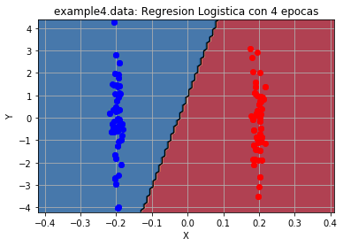

```python
%run TasasClasificador.py ./ConjuntosDatos/example4.data --regLog --epocas 4 --aprendizaje 1 --plot
```

En este caso vemos que de los 4 ficheros de datos es el unico que se clasifica bien, eso es porque las clases no estan mazcladas y estan divididas en dos grupos, por tanto mediante una recta es posible dejarlas divididas correctamente y obtenemos el 0% de error.

#### Usando la libreria de Sklearn

```python
%run TasasClasificador.py ./ConjuntosDatos/example1.data --regLog --epocas 4 --aprendizaje 1 --sklearn
```

```
  Fichero:  example1.data
  - Porcentaje Entrenamiento en Validacion simple 70.00%
  - Numero de Particiones en Validacion cruzada:  5
  - Usando la libreria Sklearn
----------------------------------------------------
  El error con Validacion Simple es del 70.25%
  El error medio con Validacion Cruzada es del 58.75% Con una desviacion de 5.30%
```

```python
%run TasasClasificador.py ./ConjuntosDatos/example2.data --regLog --epocas 4 --aprendizaje 1 --sklearn
```

```
  Fichero:  example2.data
  - Porcentaje Entrenamiento en Validacion simple 70.00%
  - Numero de Particiones en Validacion cruzada:  5
  - Usando la libreria Sklearn
----------------------------------------------------
  El error con Validacion Simple es del 57.85%
  El error medio con Validacion Cruzada es del 58.50% Con una desviacion de 16.34%
```

```python
%run TasasClasificador.py ./ConjuntosDatos/example3.data --regLog --epocas 4 --aprendizaje 1 --sklearn
```

```
  Fichero:  example3.data
  - Porcentaje Entrenamiento en Validacion simple 70.00%
  - Numero de Particiones en Validacion cruzada:  5
  - Usando la libreria Sklearn
----------------------------------------------------
  El error con Validacion Simple es del 47.93%
  El error medio con Validacion Cruzada es del 49.50% Con una desviacion de 4.23%
```

```python
%run TasasClasificador.py ./ConjuntosDatos/example4.data --regLog --epocas 4 --aprendizaje 1 --sklearn
```

```
  Fichero:  example4.data
  - Porcentaje Entrenamiento en Validacion simple 70.00%
  - Numero de Particiones en Validacion cruzada:  5
  - Usando la libreria Sklearn
----------------------------------------------------
  El error con Validacion Simple es del 0.00%
  El error medio con Validacion Cruzada es del 0.00% Con una desviacion de 0.00%
```

Comparamos los resultados para validación simple entre nuestro clasificador de Regresión Logística y el de la librería de Sklearn

| Fichero | Nuestro Clasificador | Sklearn |
| --- | --- | --- |
| example1.data | 55,00% | 70,25% |
| example2.data | 49,17% | 57,85% |
| example3.data | 47,50% | 47,93% |
| example4.data | 0,00% | 0,00% |

Vemos que son bastante parecidos entre ambos, y que a excepción de example4 el resto tienen errores bastante grandes, esto es porque son datos con dispersion o que son dificiles de clasificar usando una recta.

### Conclusiones Finales

La elección del clasificador depende no solo de su eficacia computacional sino de los datos que se tienen. Como hemos visto hay casos en los que KNN es perfecto en la clasificación, y para ese mismo caso Regresión Logísitica es bastante mas malo aunque tarde menos en ejecutarse.

Lo mismo con usar normalización o no, si todos los datos están en la misma escala no es necesaria aplicar la normalización y ahorramos tiempo de ejecución, pero en algunos casos es necesario para obtener predicciones correctas con una tasa de fallo pequeña. Esto ultimo es porque los datos no estan representados en la misma escala.

### Información sobre nuestro programa principal TasasClasificador.py

El fichero TasasClasificador.py es el main implementado para probar cualquier clasificador de los implementados. Este recibe por argumento los parametros necesarios para la ejecución del clasificador seleccionado (tambien por parámetro). Si se ejecuta con el parámetro -h ó --help se muestran todos los parámetros que acepta.

A continuación vamos a detallar todos estos parámetros para una correcta ejecución:

- **--porcentaje** Numero real que representa el porcentaje de Entrenamiento para Validación Simple
- **--particiones** Número entero para la validación cruzada
- **--NB** Utiliza el Clasificador de Naive Bayes
- **--KNN** Utiliza el Clasificador de Vecinos Próximos
- **--regLog** Utiliza el Clasificador de Regresión Logística
- **--laPlace** Utiliza Corrección de La Place (Sólo válido para Naive Bayes)
- **--k** Lista de números enteros que indica los vecinos con los que comparar (Sólo válido para KNN)
- **--norm** Indica que se quiere utilizar normalización en los datos (Sólo válido para KNN)
- **--epocas** Entero que indica el número de epocas que entrenar (Sólo válido para Regresión Logística)
- **--aprendizaje** Real que indica la constante de aprendizaje (Sólo válido para Regresón Logística)
- **--plot** Genera la gráfoca del clasificador especificado (No válido con NB) Todos estos parámetros son opcionales, el único obligatorio es la ruta donde se encuentra el fichero de datos. Si no se introduce ninguno de los parámetros anteriormente descritos el programa tomará valores por defecto. Estos son:
- Porcentaje de Entrenamiento del 70%
- Número de particiones para Validación Cruzada de 5
- Clasificador de Naive Bayes sin correción de La Place